# AI-Use Ham I Right?

STAT 330 Portfolio Project

Author

Zachary Jorgensen, Ryan Bird, Gavin Weber

**Group members:** Ryan Bird. Zach Jorgensen, Gavin Weber

# Question

Can we accurately predict the price of a ham product based on the size of the package, the time of maturation, whether it’s organic, smoked, or domestically produced? This answer matters because it enables companies to predict performance in certain markets and thus drive strategic planning and decision making.

# Variables

```r
library(tidyverse)
library(car)
library(rsample)
library(yardstick)
library(recipes)

ham <- read.csv("european-ham.csv")
ham_simple <- ham |>
  select(price, packsize, maturation, smoked, organic, domestic) |>
  mutate(
    domestic = as.factor(domestic),
    organic = as.factor(organic),
    smoked = as.factor(smoked)
  )
```

Our “ham” dataset has 768 observations of 23 variables. Each observation represents the characteristics of one ham from a European Seller located using online shopping data. Our response variable is price (the price per 100g in €) and our candidate predictors are packsize (Size of the ham package, g), maturation (# of months the ham has matured), organic (Indicator, 1 = labeled organic, 0 = Otherwise ), domestic (Indicator, 1 = domestic, 0 = foreign), and smoked (Indicator, 1 = smoked, 0 = Otherwise).

Data was collected from the CMU S&DS Data Repository. The website states that this dataset is meant to be open source and available for instructors and students; no permission, representation, measurement, or ethical concerns are found.

# Baseline Result

## Baseline model

```r
ham_model <- lm(price ~ packsize + maturation + I(organic) + I(smoked) + I(domestic), data = ham_simple)
summary(ham_model)
```

```
Call:
lm(formula = price ~ packsize + maturation + I(organic) + I(smoked) +
    I(domestic), data = ham_simple)

Residuals:
    Min      1Q  Median      3Q     Max
-3.7251 -1.2119 -0.2149  0.7291 26.9567

Coefficients:
              Estimate Std. Error t value Pr(>|t|)
(Intercept)   3.081342   0.271550  11.347  < 2e-16 ***
packsize     -0.011399   0.001704  -6.691 4.30e-11 ***
maturation    0.235852   0.012072  19.537  < 2e-16 ***
I(organic)1   3.476012   0.444754   7.816 1.82e-14 ***
I(smoked)1    0.493028   0.259609   1.899   0.0579 .
I(domestic)1 -0.363159   0.162602  -2.233   0.0258 *
---
Signif. codes:  0 '***' 0.001 '**' 0.01 '*' 0.05 '.' 0.1 ' ' 1

Residual standard error: 2.188 on 762 degrees of freedom
Multiple R-squared:  0.4409,    Adjusted R-squared:  0.4373
F-statistic: 120.2 on 5 and 762 DF,  p-value: < 2.2e-16
```

```r
confint(ham_model)
```

```
                   2.5 %       97.5 %
(Intercept)   2.54826633  3.614417365
packsize     -0.01474344 -0.008054545
maturation    0.21215361  0.259550442
I(organic)1   2.60292424  4.349099857
I(smoked)1   -0.01660662  1.002661865
I(domestic)1 -0.68235974 -0.043957978
```

Holding maturation time and status of organic, smoked and domestic constant, for every additional 100 grams of ham contained in the package, we would expect to see a decrease of 1.14 € on average (95% CI, -1.47 to -0.81). Our R^2 is not exceptionally high (~44.1%); adding additional meaningful predictors could increase our ability to accurately predict ham prices.

## Check Assumptions

### LINE

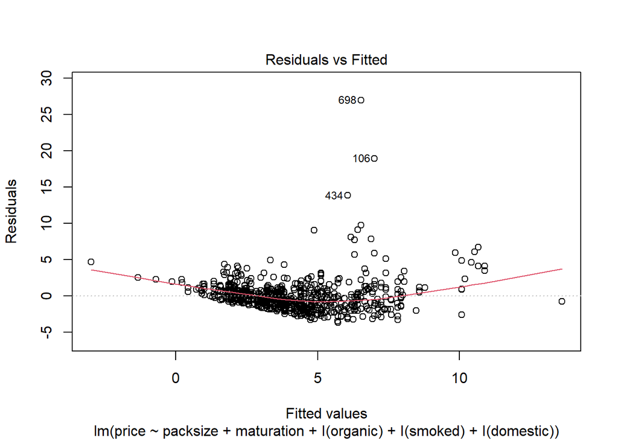

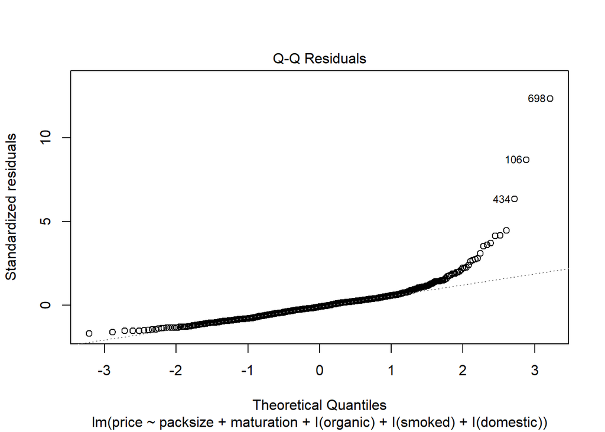

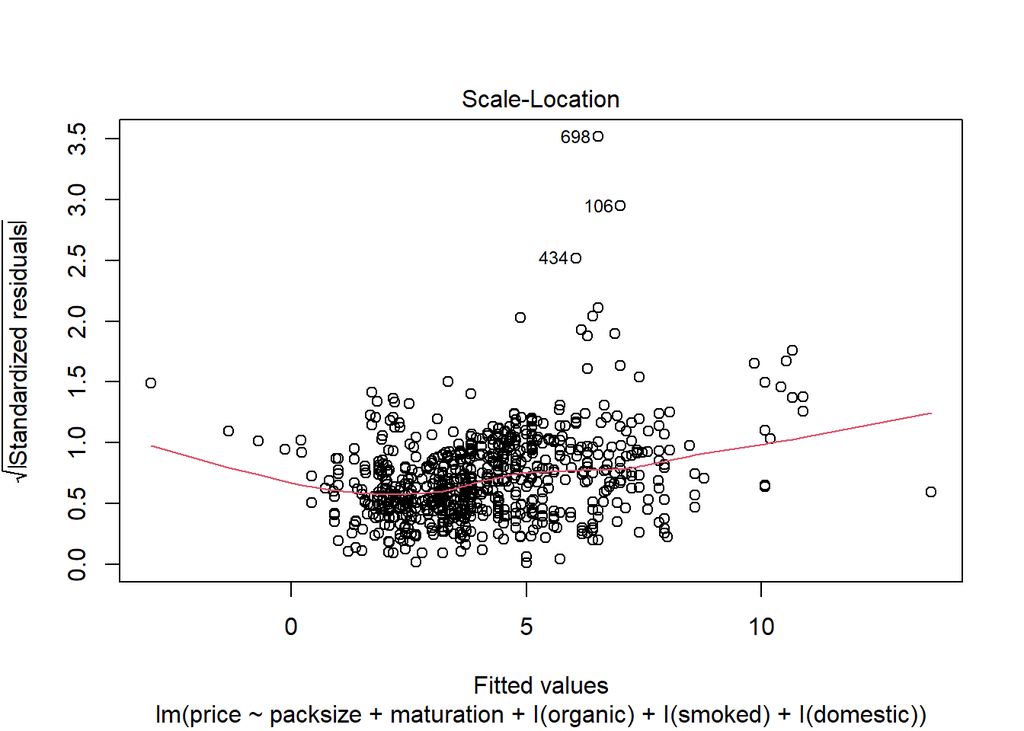

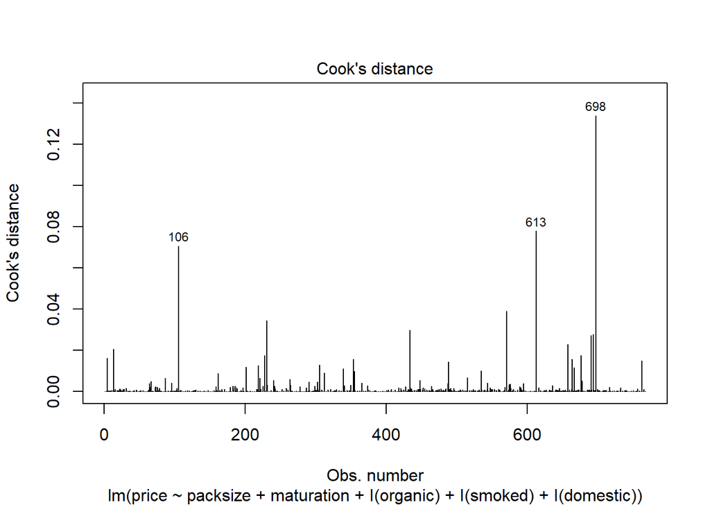

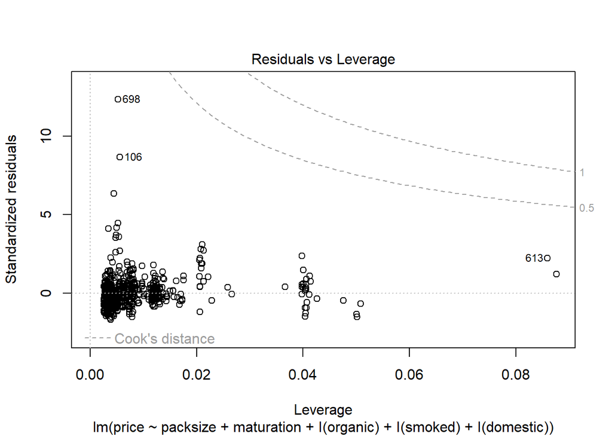

```r
plot(ham_model, which = 1:5)
```

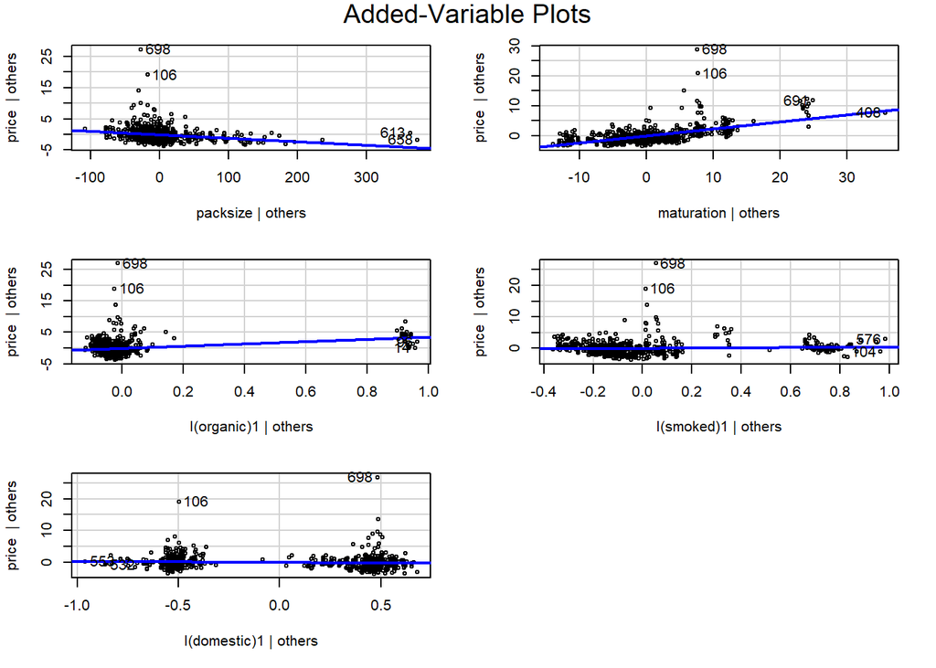

```r
avPlots(ham_model)
```

```r
vif(ham_model)
```

```
   packsize  maturation  I(organic)   I(smoked) I(domestic)
   1.109990    1.243368    1.038097    1.182776    1.050714
```

We are seriously concerned about the normality assumption being violated, and have minor doubts about the linearity. We suspect that there are a few overly influential observations as well. There does not appear to be any instances of multi-collinearity.

### Investigate Outliers

```r
ham_no_outliers <- ham_simple[-c(698, 613, 106), ]
ham_model_no_outliers <- lm(price ~ packsize + maturation + I(organic) + I(smoked) + I(domestic), data = ham_no_outliers)
summary(ham_model_no_outliers)
```

```
Call:
lm(formula = price ~ packsize + maturation + I(organic) + I(smoked) +
    I(domestic), data = ham_no_outliers)

Residuals:
    Min      1Q  Median      3Q     Max
-3.6057 -1.1083 -0.1671  0.7869 13.9713

Coefficients:
              Estimate Std. Error t value Pr(>|t|)
(Intercept)   3.177478   0.230644  13.777  < 2e-16 ***
packsize     -0.011815   0.001484  -7.962 6.15e-15 ***
maturation    0.224985   0.010098  22.280  < 2e-16 ***
I(organic)1   3.480174   0.371530   9.367  < 2e-16 ***
I(smoked)1    0.476361   0.216788   2.197  0.02830 *
I(domestic)1 -0.373356   0.135999  -2.745  0.00619 **
---
Signif. codes:  0 '***' 0.001 '**' 0.01 '*' 0.05 '.' 0.1 ' ' 1

Residual standard error: 1.827 on 759 degrees of freedom
Multiple R-squared:  0.5113,    Adjusted R-squared:  0.508
F-statistic: 158.8 on 5 and 759 DF,  p-value: < 2.2e-16
```

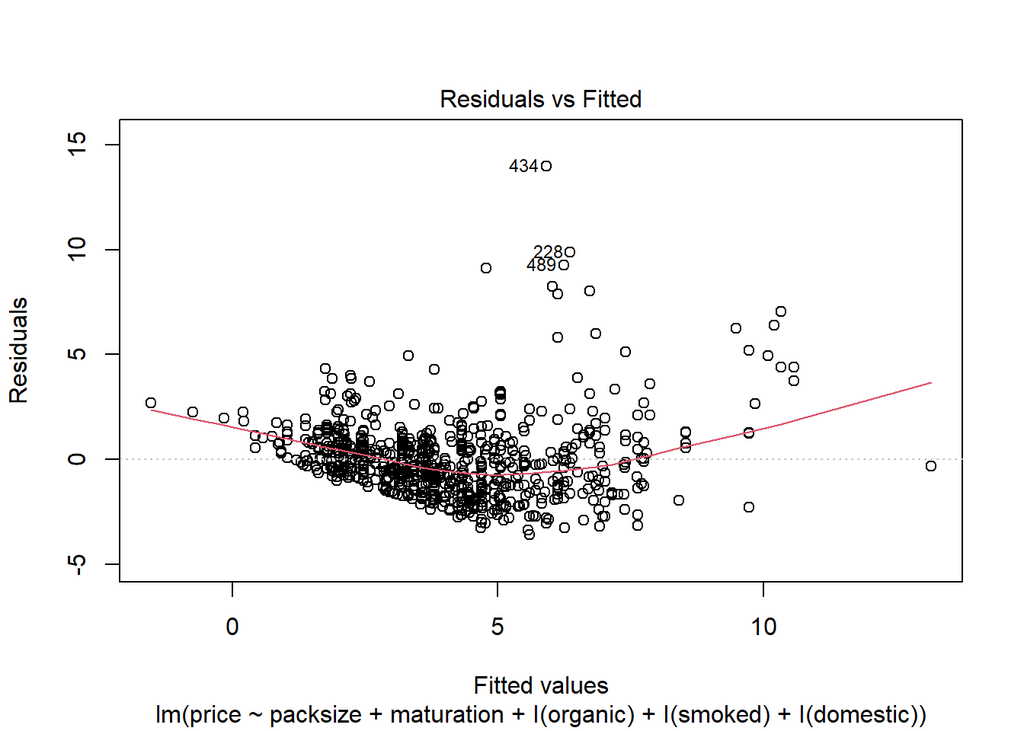

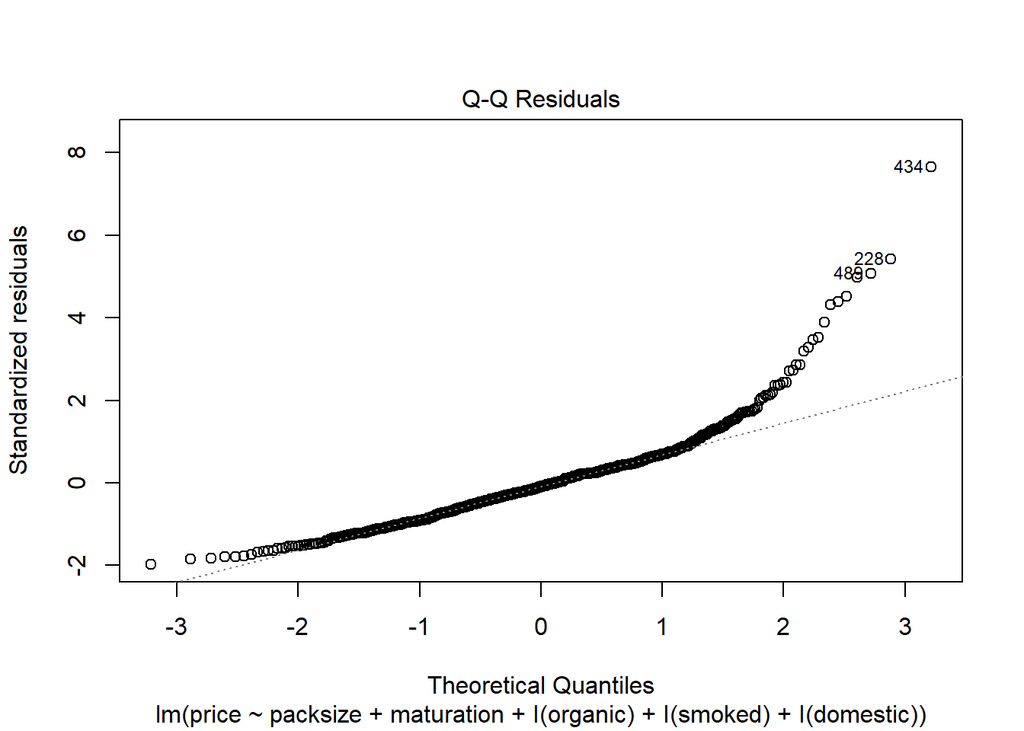

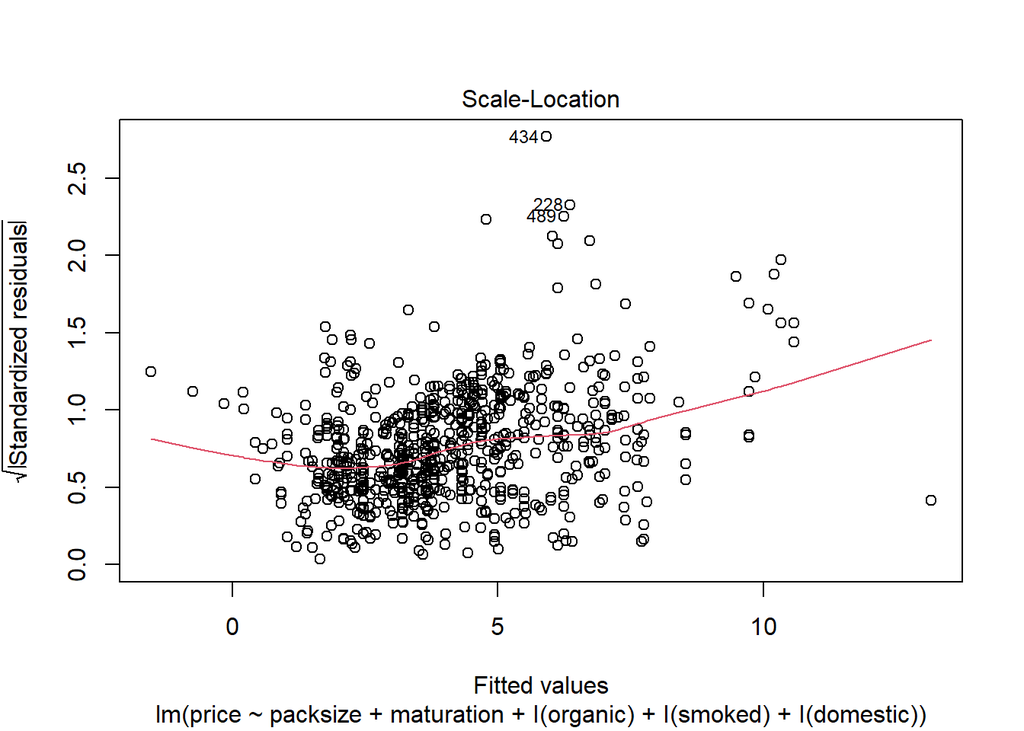

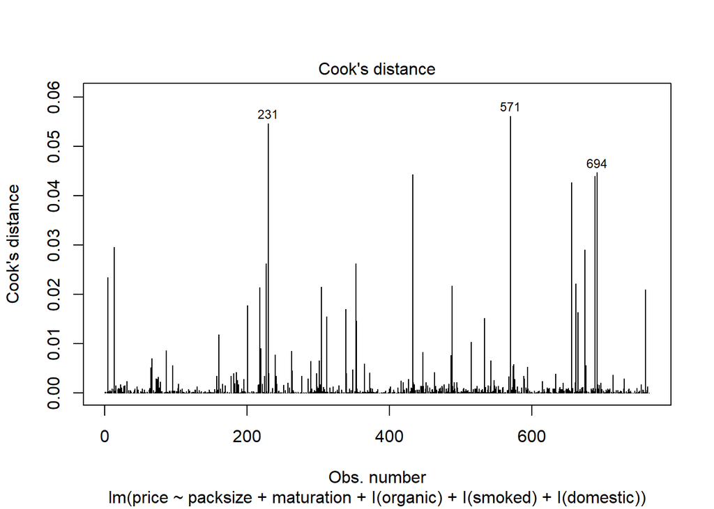

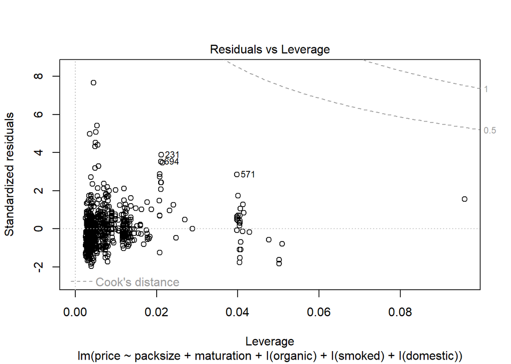

```r
plot(ham_model_no_outliers, which = 1:5)
```

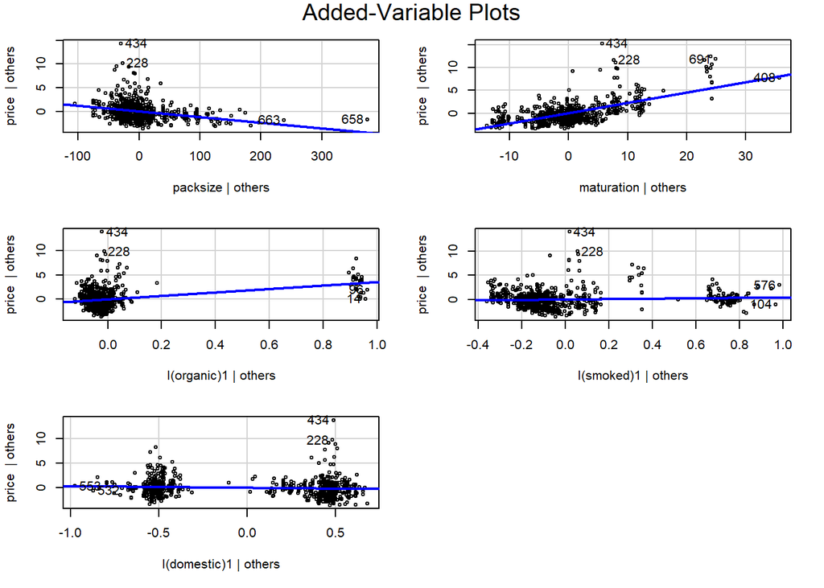

```r
avPlots(ham_model_no_outliers)
```

```r
vif(ham_model_no_outliers)
```

```
   packsize  maturation  I(organic)   I(smoked) I(domestic)
   1.105880    1.238730    1.038953    1.182383    1.050402
```

We excluded the three most influential points but found that the assumptions were not met and now there are many other overly influential points. In order to remove all influential points we would be losing a lot of data, so we are going to include all of the data.

### Transformations

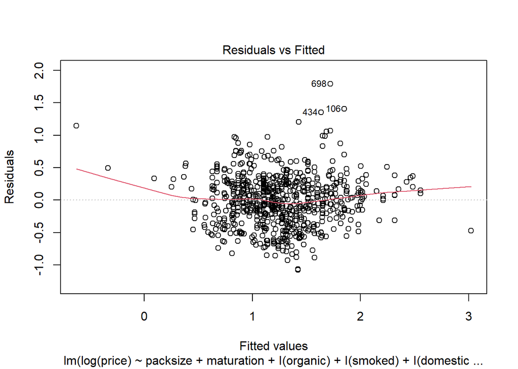

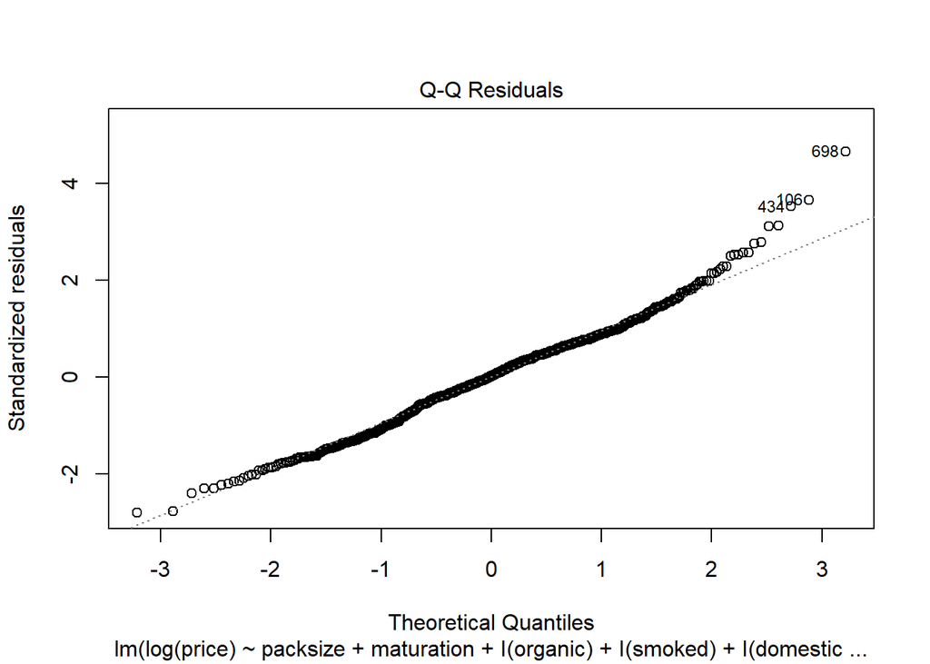

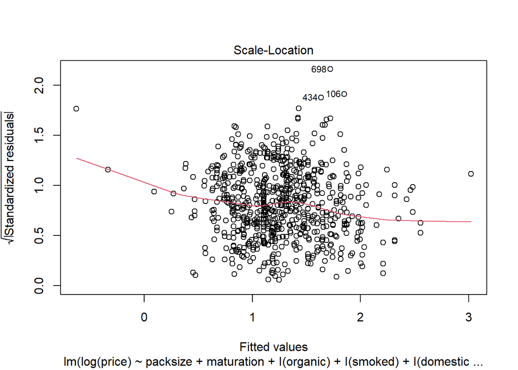

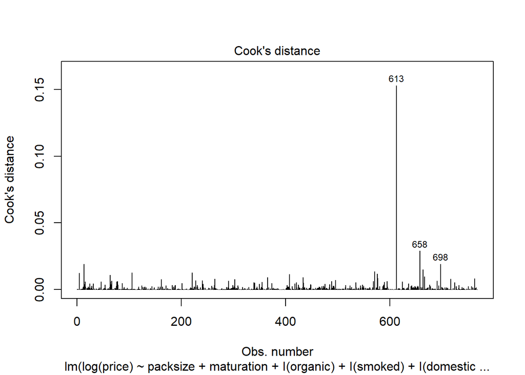

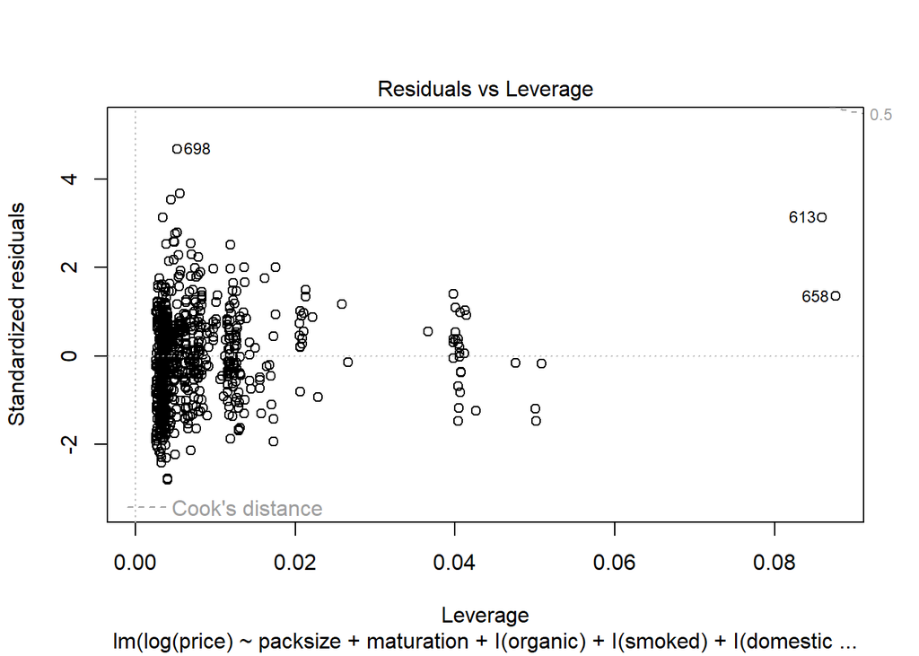

```r
trans_1 <- lm(log(price) ~ packsize + maturation + I(organic) + I(smoked) + I(domestic), data = ham_simple)
plot(trans_1, which = 1:5)
```

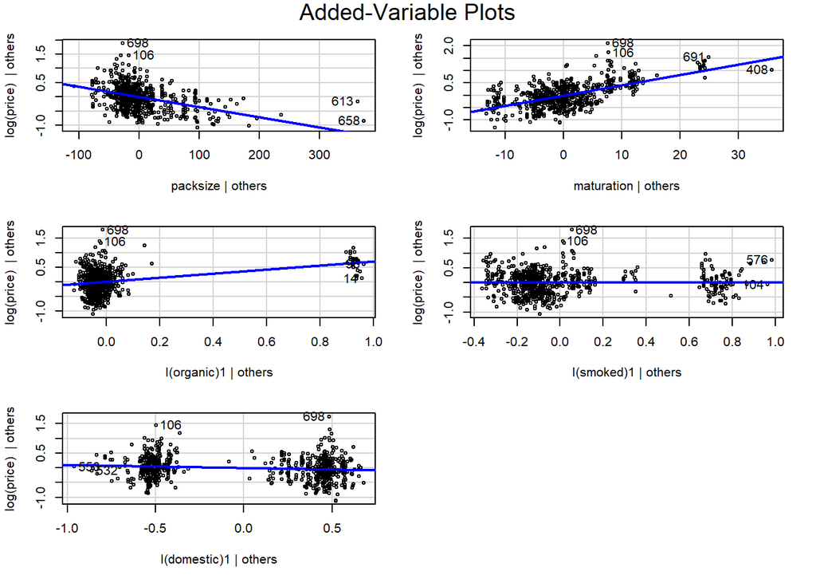

```r
avPlots(trans_1)
```

```r
vif(trans_1)
```

```
   packsize  maturation  I(organic)   I(smoked) I(domestic)
   1.109990    1.243368    1.038097    1.182776    1.050714
```

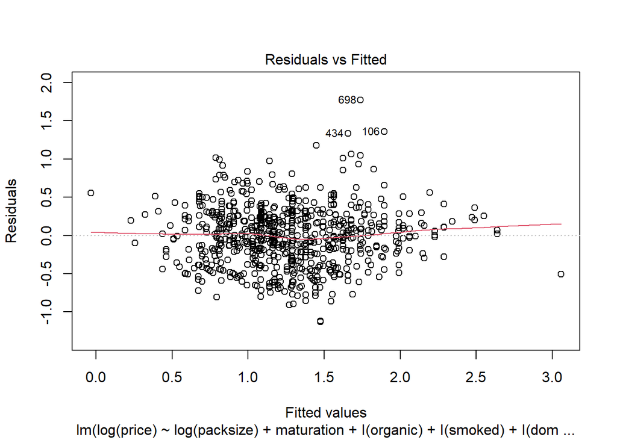

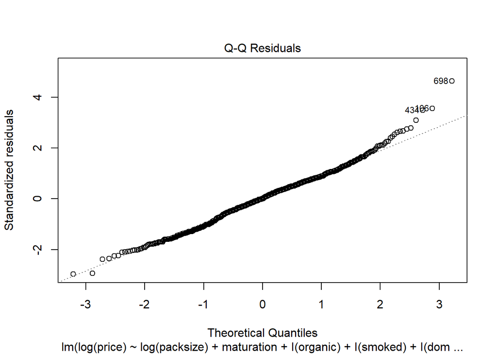

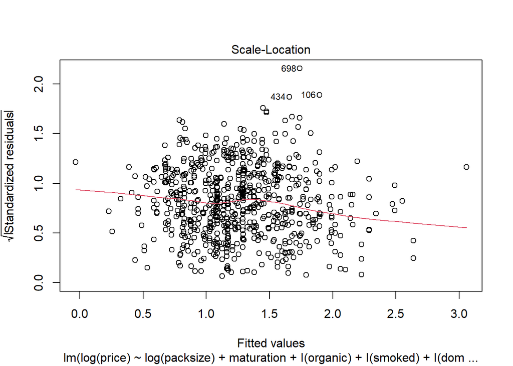

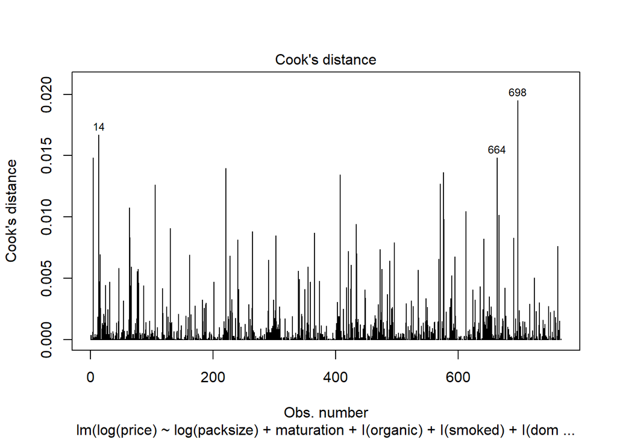

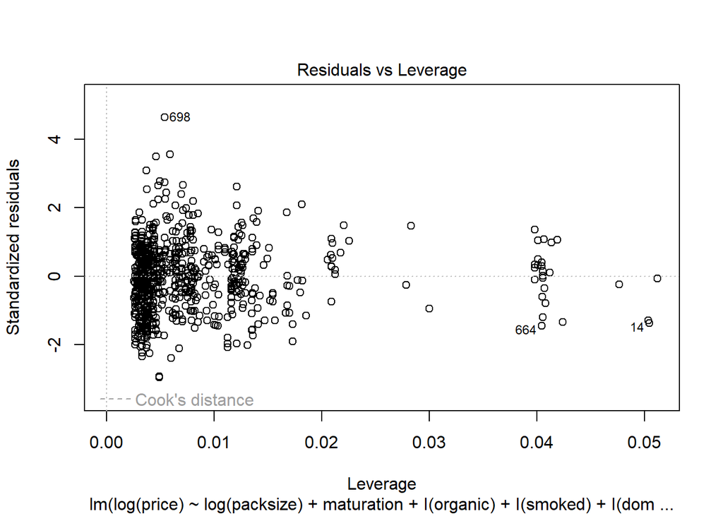

```r
trans_2 <- lm(log(price) ~ log(packsize) + maturation + I(organic) + I(smoked) + I(domestic), data = ham_simple)
plot(trans_2, which = 1:5)
```

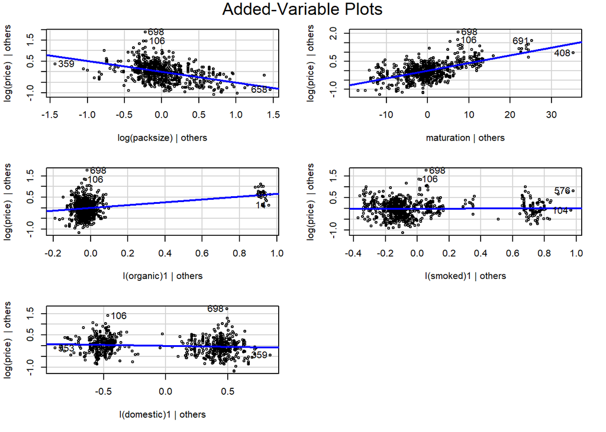

```r
avPlots(trans_2)
```

```r
vif(trans_2)
```

```
log(packsize)    maturation    I(organic)     I(smoked)   I(domestic)
     1.128096      1.247396      1.047647      1.179788      1.056420
```

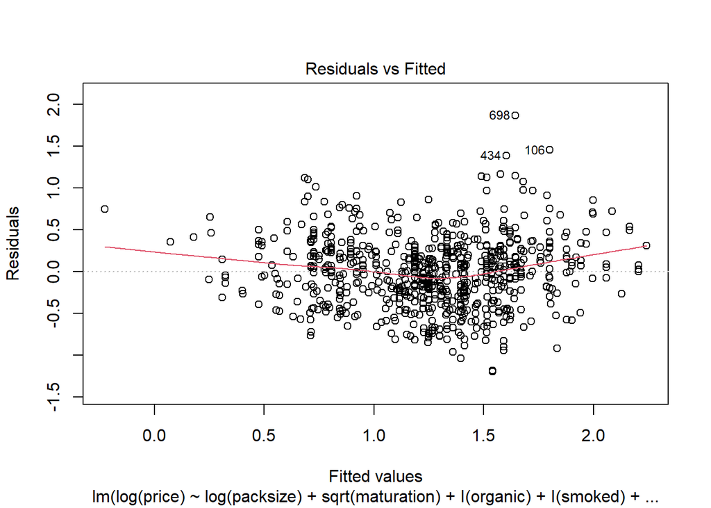

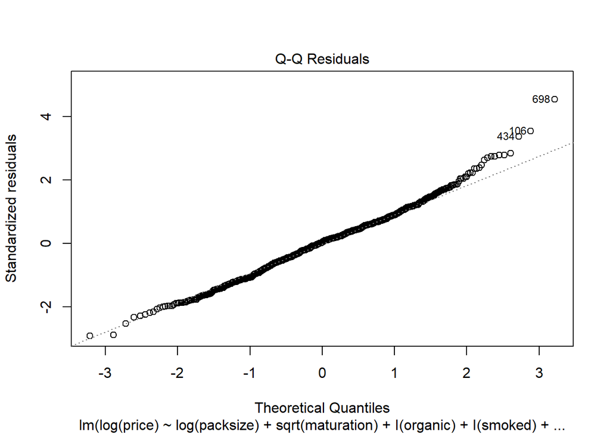

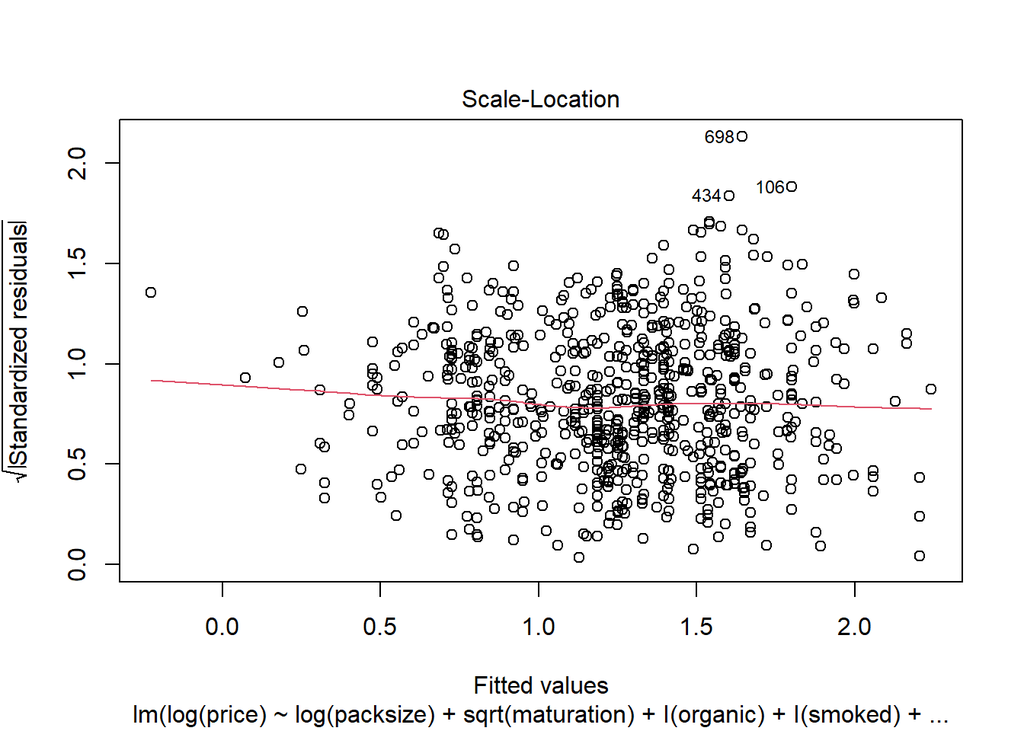

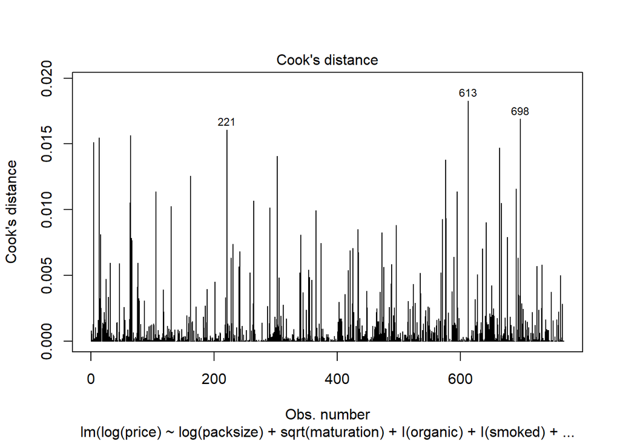

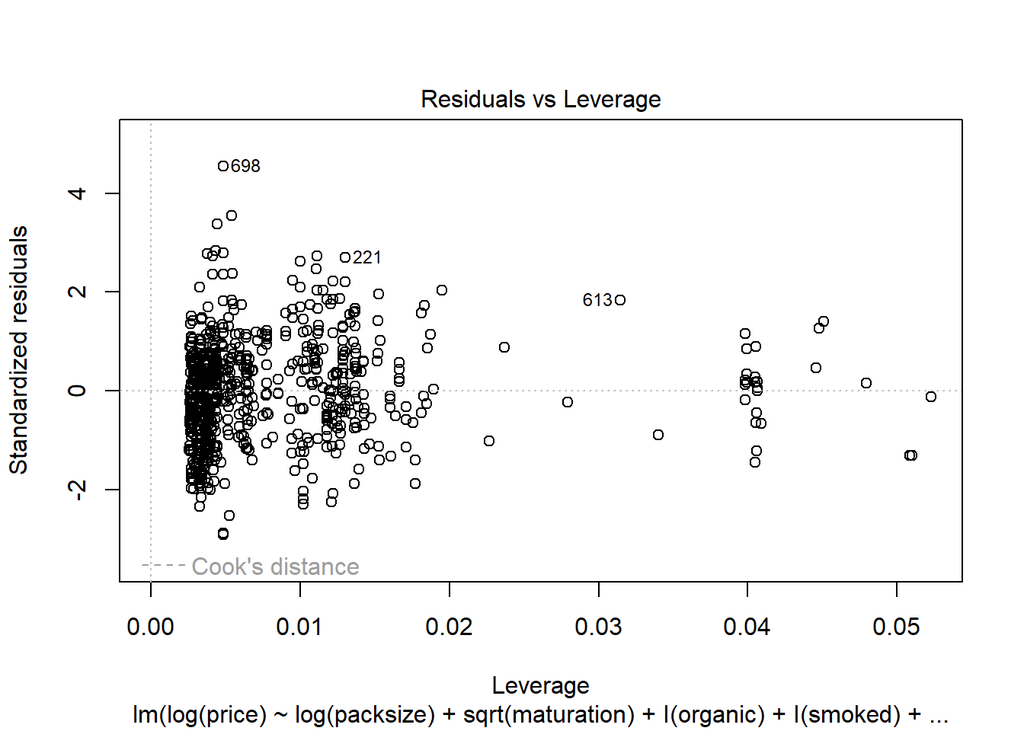

```r
trans_3 <- lm(log(price) ~ log(packsize) + sqrt(maturation) + I(organic) + I(smoked) + I(domestic), data = ham_simple)
plot(trans_3, which = 1:5)
```

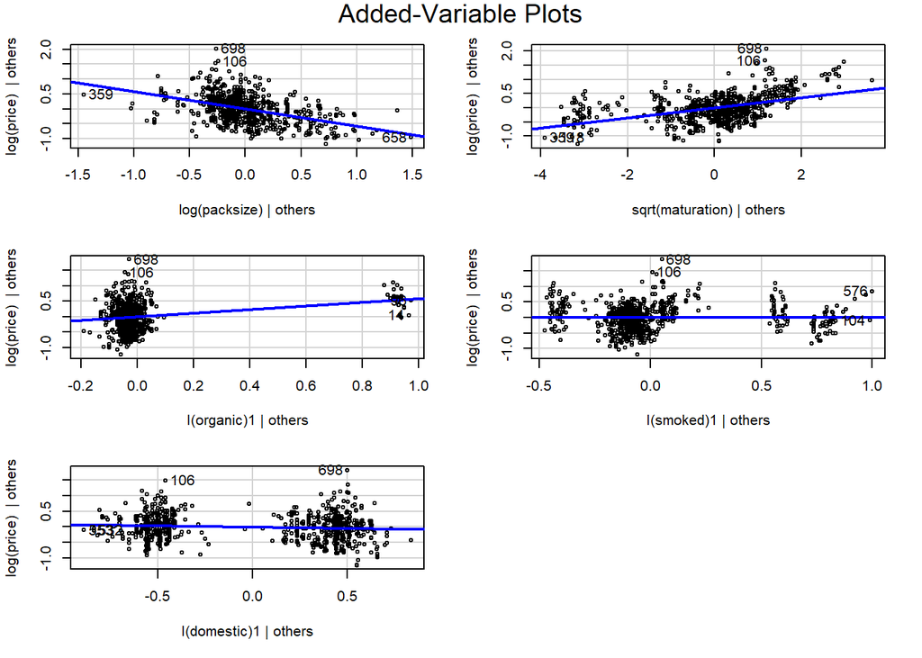

```r
avPlots(trans_3)
```

```r
vif(trans_3)
```

```
   log(packsize) sqrt(maturation)       I(organic)        I(smoked)
        1.103818         1.283877         1.039134         1.244832
     I(domestic)
        1.055831
```

### Cross Validation to determine which model is better at out of sample prediction

```r
# 1. Pre-calculate ALL math transformations so the formulas are "clean"
ham_simple2 <- ham_simple |>
  mutate(
    log_price = log(price),
    log_packsize = log(packsize),
    sqrt_maturation = sqrt(maturation)
  )

# 2. Define the formulas directly (do not use lm() here, just write the formulas)
# Notice: NO log(), NO sqrt(), NO I() anywhere in these lines!
f_trans_1 <- log_price ~ log_packsize # (Update this with your actual trans_1 variables)
f_trans_2 <- log_price ~ log_packsize + maturation + organic + smoked + domestic
f_trans_3 <- log_price ~ log_packsize + sqrt_maturation + organic + smoked + domestic
f_ham_model <- log_price ~ packsize + maturation # (Update this with your actual ham_model variables)

# 3. Create the Leave-One-Out Cross-Validation folds using the NEW dataset
set.seed(11282025)
folds <- loo_cv(ham_simple2) # IMPORTANT: changed to ham_simple2

# 4. Define the scoring function
fit_and_score <- function(split, formula_obj) {
  train_d <- analysis(split)
  test_d <- assessment(split)

  # Because the formula_obj is now clean, recipe() will work perfectly
  rec <- recipe(formula_obj, data = train_d) |>
    step_normalize(all_numeric_predictors()) |>
    prep(training = train_d)

  # Apply the scaling parameters to both train and test splits
  train_processed <- bake(rec, new_data = NULL)
  test_processed  <- bake(rec, new_data = test_d)

  # Fit the model on the standardized training data
  fit <- lm(formula_obj, data = train_processed)

  # Predict and compute RMSE on the test fold
  test_processed |>
    mutate(.pred = predict(fit, newdata = test_processed)) |>
    # IMPORTANT: Changed 'truth = price' to 'truth = log_price'
    rmse(truth = log_price, estimate = .pred) |>
    pull(.estimate)
}

# 5. Apply the function across all LOOCV folds for the four models
cv_results <- folds |>
  mutate(
    rmse_trans1 = map_dbl(splits, fit_and_score, formula_obj = f_trans_1),
    rmse_trans2 = map_dbl(splits, fit_and_score, formula_obj = f_trans_2),
    rmse_trans3 = map_dbl(splits, fit_and_score, formula_obj = f_trans_3),
    rmse_ham_model = map_dbl(splits, fit_and_score, formula_obj = f_ham_model)
  )

# 6. Reshape the data for summary and plotting
cv_long <- cv_results |>
  select(starts_with("rmse_")) |>
  pivot_longer(everything(), names_to = "model", values_to = "rmse")

# 7. Output the summary statistics
cv_long |>
  group_by(model) |>
  summarise(
    mean_rmse = mean(rmse),
    sd_rmse = sd(rmse),
    .groups = "drop"
  )
```

```
# A tibble: 4 × 3
  model          mean_rmse sd_rmse
  <chr>              <dbl>   <dbl>
1 rmse_ham_model     0.319   0.253
2 rmse_trans1        0.382   0.301
3 rmse_trans2        0.302   0.237
4 rmse_trans3        0.323   0.258
```

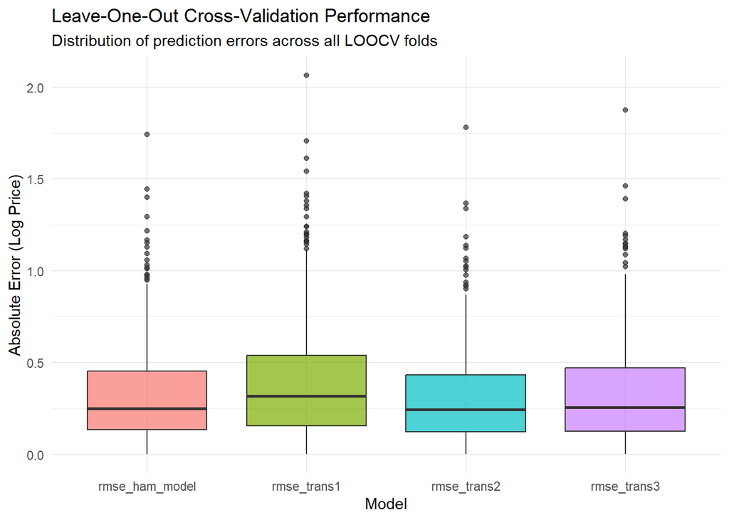

```r
ggplot(cv_long, aes(x = model, y = rmse, fill = model)) +
  geom_boxplot(alpha = 0.7) +
  theme_minimal() +
  labs(
    title = "Leave-One-Out Cross-Validation Performance",
    subtitle = "Distribution of prediction errors across all LOOCV folds",
    x = "Model",
    y = "Absolute Error (Log Price)"
  ) +
  theme(legend.position = "none")
```

# Limitation/Opportunity Found

There are many overly influential points, but we decided we’re just going to need to include them.

# Beyond-course extension planned ways to verify it

We are planning on using Spatial Bayesian regression with our data. We will verify the suggestion and methods by analyzing scientific literature, and once we have a better basic understanding of what Bayesian Spatial Regression is we will come up with a detailed plan to verify it.